# Logistic Regression Package: log.reg.11

Group 11: Charles Benfer, Ernest Asante, Rongjing Xia

11-30-2023

### Github Link

The link to our github repository can be found [here](https://github.com/R-4-Data-Science/Final-Project-Group-11.git)

### Introduction

This is an R package for performing logistic regression, implemented through numerical optimization. This package contains the basic functions needed to perform logistic regression, including estimating a vector of coefficients `β` containing independent/predictor variables and intercepts, confidence intervals for `β`, a fitted logistic curve plot of the response, and the resulting “confusion matrix” and plotting each cut_off Plot of different indicator values corresponding to the values. Also includes help documentation for all functions.

### Install the package

First, users can download the latest package through github through the following code ‘devtools::install_github(“R-4-Data-Science/Final-Project-Group-11”)’.(If the user does not have the ‘devtools’ package installed, this package needs to be installed first. The user also needs the MASS package.)

```r
devtools::install_github("R-4-Data-Science/Final-Project-Group-11")
library(log.reg.11)
library(MASS)
```

Next, we use the `bank` data set from the Canvas page to demonstrate our functions. We will focus on regressing on whether the person defaulted or not based on age and balance, so we have to modify our data a little to fit those needs.

```r
test_data <- read.csv('bank.csv', sep = ';')
for(i in 1:nrow(test_data)){

  if(test_data[i,5]=='no'){test_data[i,5] <- 0}
  else{test_data[i,5] <- 1}
}
test_data[,5] <- as.integer(test_data[,5])
```

### 1. Finding the Betas: `log_betas`

This function will spit out the desired beta values for the log loss function. The function `log_loss` is first defined in the package, given as a premise a number representing a given loss. The user will be shown a list in the output, where the first part `par` is the betas. Y representing the column of the data that you want to be the response variable and X representing the column(s) of the data that you want to be the predictor variable(s).

```r
test_resp <- 5
test_pred <- c(1,6)
log_betas(Data = test_data, Y = test_resp, X = test_pred)
```

```
## $par
##             [,1]
## [1,]  0.03105936
## [2,] -0.09179430
## [3,] -0.00277739
##
## $value
## [1] 327.0473
##
## $counts
## function gradient
##      164       NA
##
## $convergence
## [1] 0
##
## $message
## NULL
```

### 2. Bootstrap Logistic Regression Confidence Intervals: `bootstrap_logistic_confidence`

This function will help the user calculate bootstrap confidence intervals for the coefficients estimated by a logistic regression model. Next we will continue to use the data just now to show the confidence interval calculated by our function.

```r
results <- suppressWarnings(bootstrap_logistic_confidence(test_data, test_resp, test_pred))
print(results)
```

```
##           Actual       Lower        Upper
## [1,]  0.03105936 -2.42266224  2.484780972
## [2,] -0.09179430 -0.15465828 -0.028930316
## [3,] -0.00277739 -0.00330985 -0.002244931
```

### 3. Plot of the fitted logistic curve to the responses: `logistic_plot`

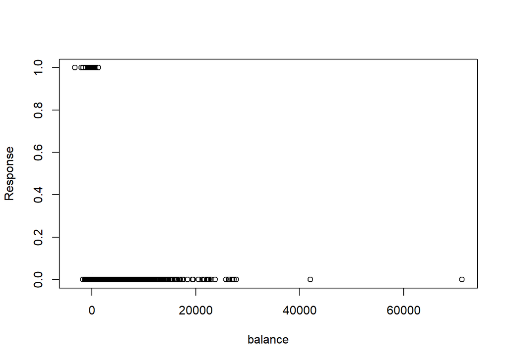

```r
logistic_plot(test_data, Resp = 5, Pred= 6)
```

### 4. Confusion matrix and related indicators: `confusion_matrix`

This function help user create the confusion matrix and also output the following metrics: prevalence, accuracy, sensitivity, specificity, false discovery rate, and diagnostic odds ratio based on this cut-off value 0.5. This function will output a list including the values of the above indicators, in the part of the corresponding name. The example:

```r
result <- confusion_matrix(Data = test_data, X=test_pred, y=test_resp, cut_off = 0.5)
print(result)
```

```
## $confuse_matrix
##                 Predicted Positive Predicted Negative
## Actual Positive               4441                 73
## Actual Negative                  4                  3
##
## $prevalence
## [1] 0.01681044
##
## $accuracy
## [1] 0.9829684
##
## $sensitivity
## [1] 0.03947368
##
## $specificity
## [1] 0.9991001
##
## $false_discovery_rate
## [1] 0.5714286
##
## $diagnostic_odds_ratio
## [1] 45.62671
```

### 5. Plot different cut_off value versus indicators: `plot_confusion_matrix`

[figure not shown]

```r
plot_confusion_matrix(Data = test_data, y = test_resp,X = test_pred , value_name = 'false_discovery_rate')
```

```r
# The example for not exist.
plot_confusion_matrix(Data = test_data, y = test_resp,X = test_pred , value_name = 'false_discovery')
```

```
## false_discovery do not exist.
```

### 6. For the bonus part

Our package created a shiny app that allows the used to view each of the plots by making a selection from a dropdown menu.

Framework reference link for this introduction:https://chat.openai.com/share/d590f325-5ab6-4642-98d4-127034991dbb